# phm_engine_classification

## Engine Health Classification and the limits of benchmark scoring

#### In helicopter engines, the gap between what torque the engine produces and what torque it should produce is called the torque margin, and it's used to assess engine health in this competition.

#### [The PHM Society 2024 Data Challenge](https://data.phmsociety.org/phm2024-conference-data-challenge/) asked competing teams to predict engine health from seven in-flight measurements, across two tasks: classify each observation as healthy or faulty, and estimate the torque margin as a probability distribution. This report covers the classification task only.

#### A Random Forest seemed like a good first pass model for engine classification, as I'm not very familiar with the domain of helicopter performance. RFs can model messy, nonlinear interactions (without any feature engineering), and do so while making few assumptions about how the system will behave.

| Feature | Plain English | Unit |
| --- | --- | --- |
| trq_measured | Actual output torque | % |
| oat | Outside air temperature | °C |
| mgt | Gas temperature inside the engine | °C |
| pa | Pressure altitude | ft |
| ias | Indicated airspeed | kts |
| np | Power turbine spin speed | % |
| ng | Gas generator spin speed | % |

```python
import math

import pandas as pd
import numpy as np
import matplotlib.pyplot as plt
from matplotlib.lines import Line2D

from sklearn.model_selection import train_test_split
from sklearn.preprocessing import StandardScaler
from sklearn.ensemble import RandomForestClassifier
from sklearn.metrics import accuracy_score, f1_score
from sklearn.decomposition import PCA

LABELED_COLOR   = "#e97e05"
UNLABELED_COLOR = "#0c00b3"
```

```python
X = pd.read_csv('phm_dataset/Data_Challenge_PHM2024_training_data/X_train.csv')
y = pd.read_csv('phm_dataset/Data_Challenge_PHM2024_training_data/y_train.csv')
X = X.drop(columns='id')
y_state  = y['faulty']
y_score  = y['trq_margin']

X_unlabeled1 = pd.read_csv('phm_dataset/Data_Challenge_PHM2024_training_data/X_test.csv')
X_unlabeled2 = pd.read_csv('phm_dataset/Data_Challenge_PHM2024_training_data/X_validation.csv')
X_unlabeled  = pd.concat([X_unlabeled1, X_unlabeled2]).drop(columns='id')

# does this conversion have any net effect on the model?
# probably not, but as a chemE it makes me happy
def conv_C_to_K(df):
    return df + 273.15

X[['oat', 'mgt']] = conv_C_to_K(X[['oat', 'mgt']])
X_unlabeled[['oat', 'mgt']] = conv_C_to_K(X_unlabeled[['oat', 'mgt']])

label_map = {
    "trq_measured": "Measured Torque (trq_measured)",
    "oat": "Outside Air Temperature (oat)",
    "mgt": "Measured Gas Temperature (mgt)",
    "pa": "Pressure Altitude (pa)",
    "ias": "Indicated Airspeed (ias)",
    "np": "Power Turbine Speed (np)",
    "ng": "Gas Generator Speed (ng)",
}

X_train, X_test, y_train, y_test = train_test_split(
    X, y_state, test_size=0.5, random_state=0, stratify=y_state
)

scaler = StandardScaler()
X_train_scaled = scaler.fit_transform(X_train)
X_test_scaled  = scaler.transform(X_test)
X_unlabeled_scaled     = scaler.transform(X_unlabeled[X_train.columns])

RF = RandomForestClassifier(random_state=123)
RF.fit(X_train_scaled, y_train)

preds = RF.predict(X_test_scaled)
print('F1 Score: ', round(f1_score(y_test, preds), 5))
```

```
F1 Score:  0.99866
```

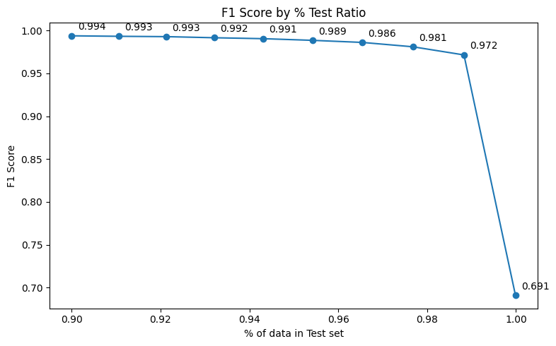

```python
# like linspace but fancier
split_ratios = [round(n, 4) for n in list(np.geomspace(0.9, 0.9999, num=10))]
rows = []

for ratio in split_ratios:
    Xtr, Xte, ytr, yte = train_test_split(X, y_state, test_size=ratio, random_state=0)
    sc_ = StandardScaler()
    RF_ = RandomForestClassifier(random_state=123)
    RF_.fit(sc_.fit_transform(Xtr), ytr)
    preds = RF_.predict(sc_.transform(Xte))
    rows.append({
        'Ratio': ratio,
        'Train size': len(Xtr),
        'Test size':  len(Xte),
        'Accuracy':   round(accuracy_score(yte, preds), 5),
        'F1':         round(f1_score(yte, preds), 5),
    })


split_df = pd.DataFrame(rows)

fig, ax = plt.subplots(figsize=(8, 5))
x = split_df["Ratio"].to_numpy()
y = split_df["F1"].to_numpy()

ax.plot(x, y, marker="o")
ax.set_xlabel('% of data in Test set')
ax.set_ylabel('F1 Score')
ax.set_title('F1 Score by % Test Ratio')
for xi, yi in zip(x, y):
    ax.annotate(f"{yi:.3f}", (xi, yi), xytext=(6, 6), textcoords="offset points")

plt.tight_layout()
plt.savefig('figures/split_ratios.png')
plt.show()
```

#### While a high F1 score might look nice on paper, the competition was scored against unseen data collected from different engines. Can we expect equally good performance on that dataset as well? To investigate, we first looked at Feature Importance in the RF model.

#### The two most important features were environmental: Outside Air Temperature and Atmospheric Pressure. We might expect that conditions vary significantly in different operating environments, and our training data only covers a small portion of that feature-space

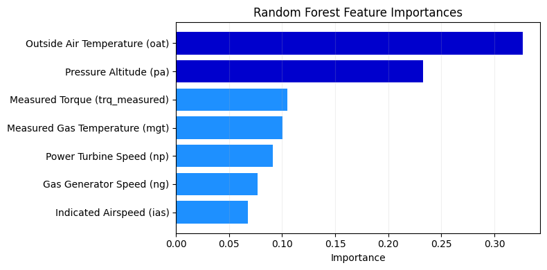

```python
importances = pd.Series(RF.feature_importances_, index=X_train.columns).sort_values()
importances_plot = importances.rename(index=label_map)

fig, ax = plt.subplots(figsize=(8, 4))

colors = ["dodgerblue"] * len(importances_plot)
colors[-1] = "mediumblue"
colors[-2] = "mediumblue"

ax.barh(importances_plot.index, importances_plot.values, color=colors, linewidth=0.6)

ax.set_xlabel("Importance")
ax.set_title("Random Forest Feature Importances")
ax.grid(axis="x", alpha=0.2)

plt.tight_layout()
plt.savefig("figures/feature_importance.png", dpi=200, bbox_inches="tight")
plt.show()
```

#### Comparing the training and unseen data directly: the histograms look similar at first glance, suggesting the two sets of engines aren't that different. But histograms look at each feature in isolation, which isn't the whole story.

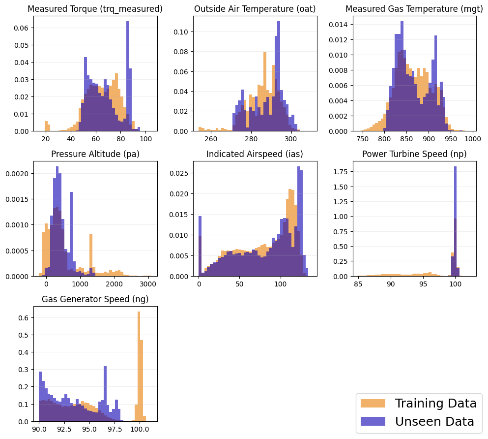

```python
features = X_train.columns.tolist()
ncols, n = 3, len(features)
nrows = math.ceil(n / ncols)

fig, axes = plt.subplots(nrows, ncols, figsize=(10, 3 * nrows), squeeze=False)

for i, col in enumerate(features):
    r, c = divmod(i, ncols)
    ax = axes[r][c]
    a    = X_train[col].to_numpy()
    b    = X_unlabeled[col].to_numpy()
    bins = np.histogram_bin_edges(np.concatenate([a, b]), bins=40)
    ax.hist(a, bins=bins, density=True, alpha=0.6, color=LABELED_COLOR,   label='Training Data')
    ax.hist(b, bins=bins, density=True, alpha=0.6, color=UNLABELED_COLOR, label='Unseen Data')
    ax.set_title(label_map.get(col, col), fontsize=12)
    ax.grid(axis='y', alpha=0.2)

for j in range(n, nrows * ncols):
    r, c = divmod(j, ncols)
    axes[r][c].axis('off')

handles, labels = axes[0][0].get_legend_handles_labels()
fig.legend(handles, labels, loc='lower right', frameon=True, fontsize=18)
plt.tight_layout()
plt.savefig('figures/distributions.png')
plt.show()
```

#### However,PCA tells a slightly more nuanced story. Visualizing the two primary components of the dataset shows that there is some overlap but also a lot of points (especially in the top right) where the unseen data does not overlap, and the model will have to extrapolate.

#### By eye, there are two apparent clusters in the training data. The Unseen data follows the same trend as one cluster/regime/group of data, but not the other.

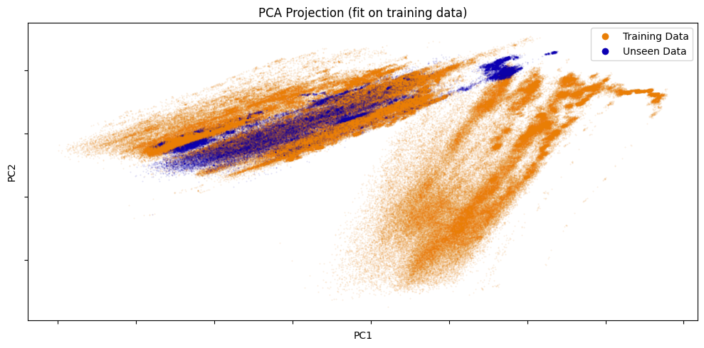

```python
pca = PCA(n_components=2, random_state=0)
Ztr = pca.fit_transform(X_train_scaled)
Zun = pca.transform(X_unlabeled_scaled)

fig, ax = plt.subplots(figsize=(10, 5))
ax.scatter(Ztr[:, 0], Ztr[:, 1], s=0.3, alpha=0.1, color=LABELED_COLOR)
ax.scatter(Zun[:, 0], Zun[:, 1], s=0.3, alpha=0.1, color=UNLABELED_COLOR)
ax.set_xlabel('PC1')
ax.set_ylabel('PC2')
ax.set_xticklabels([])
ax.set_yticklabels([])
ax.set_title('PCA Projection (fit on training data)')
ax.legend(handles=[
    Line2D([0], [0], marker='o', color='w', markerfacecolor=LABELED_COLOR,   markersize=8, label='Training Data'),
    Line2D([0], [0], marker='o', color='w', markerfacecolor=UNLABELED_COLOR, markersize=8, label='Unseen Data'),
])
plt.tight_layout()
plt.savefig('figures/pca.png')
plt.show()
```

#### Obtaining confidence scores from the Random Forest model, we can see that the model struggles with the new data. While it was highly confident (>0.99 for almost all predictions) on data similar to its training set, it demonstrates low confidence on the unseen data, evenly spread out between 0.5 (coinflip) and 1.0 (certainty)

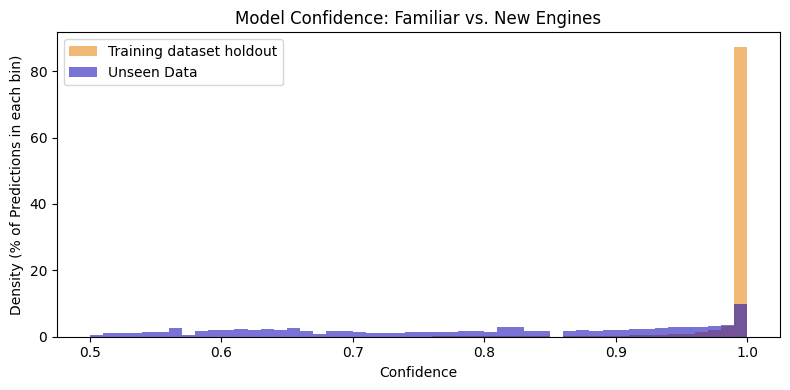

```python
p1_te = RF.predict_proba(X_test_scaled)[:, 1]
conf_te = np.maximum(p1_te, 1 - p1_te)

p1_un = RF.predict_proba(X_unlabeled_scaled)[:, 1]
conf_un = np.maximum(p1_un, 1 - p1_un)

fig, ax = plt.subplots(figsize=(8, 4))
ax.hist(conf_te, bins=50, alpha=0.55, density=True, color=LABELED_COLOR,   label='Training dataset holdout')
ax.hist(conf_un, bins=50, alpha=0.55, density=True, color=UNLABELED_COLOR, label='Unseen Data')
ax.set_xlabel('Confidence')
ax.set_ylabel('Density (% of Predictions in each bin)')
ax.set_title('Model Confidence: Familiar vs. New Engines')
ax.legend()
plt.tight_layout()
plt.savefig('figures/confidence.png')
plt.show()
```

#### Simply having tons of data won't save you if the data you have don't overlap with the range of conditions of interest (where you will apply your model).

## Next Steps

#### The competition also asked teams to estimate how far the engine is from its design torque, expressed as a probability distribution (PDF), not just a point estimate. The competition scoring was designed to strongly punish confident false negatives (classifying a bad engine as OK). This is a harder and arguably more useful task for real-world maintenance decisions.